# ++MT_ReneWindProject_LearnerNotebook_FullCode++ipynb

## Problem Statement

### Business Context

Renewable energy sources play an increasingly important role in the global energy mix, as the effort to reduce the environmental impact of energy production increases.

Out of all the renewable energy alternatives, wind energy is one of the most developed technologies worldwide. The U.S Department of Energy has put together a guide to achieving operational efficiency using predictive maintenance practices.

Predictive maintenance uses sensor information and analysis methods to measure and predict degradation and future component capability. The idea behind predictive maintenance is that failure patterns are predictable and if component failure can be predicted accurately and the component is replaced before it fails, the costs of operation and maintenance will be much lower.

The sensors fitted across different machines involved in the process of energy generation collect data related to various environmental factors (temperature, humidity, wind speed, etc.) and additional features related to various parts of the wind turbine (gearbox, tower, blades, break, etc.).

## Objective

“ReneWind” is a company working on improving the machinery/processes involved in the production of wind energy using machine learning and has collected data of generator failure of wind turbines using sensors. They have shared a ciphered version of the data, as the data collected through sensors is confidential (the type of data collected varies with companies). Data has 40 predictors, 20000 observations in the training set and 5000 in the test set.

The objective is to build various classification models, tune them, and find the best one that will help identify failures so that the generators could be repaired before failing/breaking to reduce the overall maintenance cost. The nature of predictions made by the classification model will translate as follows:

- True positives (TP) are failures correctly predicted by the model. These will result in repairing costs.
- False negatives (FN) are real failures where there is no detection by the model. These will result in replacement costs.
- False positives (FP) are detections where there is no failure. These will result in inspection costs.

It is given that the cost of repairing a generator is much less than the cost of replacing it, and the cost of inspection is less than the cost of repair.

“1” in the target variables should be considered as “failure” and “0” represents “No failure”.

## Data Description

- The data provided is a transformed version of original data which was collected using sensors.
- Train.csv - To be used for training and tuning of models.
- Test.csv - To be used only for testing the performance of the final best model.
- Both the datasets consist of 40 predictor variables and 1 target variable

## Importing necessary libraries

```python
# Installing the libraries with the specified version
!pip install pandas==1.5.3 numpy==1.25.2 matplotlib==3.7.1 seaborn==0.13.1 scikit-learn==1.2.2 imbalanced-learn==0.10.1 xgboost==2.0.3 threadpoolctl==3.3.0 -q --user
```

```python
# Libraries to help with reading and manipulating data
import pandas as pd
import numpy as np

# Libaries to help with data visualization
import matplotlib.pyplot as plt
import seaborn as sns

# To tune model, get different metric scores, and split data
from sklearn.metrics import (
    f1_score,
    accuracy_score,
    recall_score,
    precision_score,
    confusion_matrix,
    ConfusionMatrixDisplay,
    precision_recall_curve,
    roc_curve, auc
)
from sklearn import metrics

from sklearn.model_selection import train_test_split, StratifiedKFold, cross_val_score

# To be used for data scaling and one hot encoding
from sklearn.preprocessing import StandardScaler, MinMaxScaler, OneHotEncoder

# To impute missing values
from sklearn.impute import SimpleImputer

# To oversample and undersample data
from imblearn.over_sampling import SMOTE
from imblearn.under_sampling import RandomUnderSampler

# To do hyperparameter tuning
from sklearn.model_selection import RandomizedSearchCV, GridSearchCV

# To be used for creating pipelines and personalizing them
from sklearn.pipeline import Pipeline
from sklearn.compose import ColumnTransformer

# To define maximum number of columns to be displayed in a dataframe
pd.set_option("display.max_columns", None)
pd.set_option("display.max_rows", None)

# To help with model building
from sklearn.linear_model import LogisticRegression
from sklearn.tree import DecisionTreeClassifier
from sklearn.ensemble import (
    AdaBoostClassifier,
    GradientBoostingClassifier,
    RandomForestClassifier,
    BaggingClassifier,
)
from xgboost import XGBClassifier

# To suppress warnings
import warnings

warnings.filterwarnings("ignore")
```

## Loading the dataset

```python
# Load dataset from colab drive
from google.colab import drive
drive.mount('/content/drive')
```

```python
# Read the csv
train = pd.read_csv('/content/drive/MyDrive/Train.csv')
test = pd.read_csv('/content/drive/MyDrive/Test.csv')
```

```python
# Make copy of the dataframes
df_train = train.copy()
df_test = test.copy()
```

## Data Overview

- Observations
- Sanity checks

```python
# General Information about the datasets
train_info = df_train.info()
test_info = df_test.info()
```

```
<class 'pandas.core.frame.DataFrame'>
RangeIndex: 20000 entries, 0 to 19999
Data columns (total 41 columns):
 #   Column  Non-Null Count  Dtype
---  ------  --------------  -----
 0   V1      19982 non-null  float64
 1   V2      19982 non-null  float64
 2   V3      20000 non-null  float64
 3   V4      20000 non-null  float64
 4   V5      20000 non-null  float64
 5   V6      20000 non-null  float64
 6   V7      20000 non-null  float64
 7   V8      20000 non-null  float64
 8   V9      20000 non-null  float64
 9   V10     20000 non-null  float64
```

[output cut: 81 more lines]

```python
# Checking dataframe shape
df_train.shape, df_test.shape
```

```
((20000, 41), (5000, 41))
```

```python
# Checking for missing values TRAIN
train_missing = df_train.isnull().sum()

# Display results
train_missing[train_missing > 0]
```

|  | 0 |
| --- | --- |
| V1 | 18 |
| V2 | 18 |

**dtype:** int64

```python
# Checking for missing values TEST
test_missing = df_test.isnull().sum()

# Display results
test_missing[test_missing > 0]
```

|  | 0 |
| --- | --- |
| V1 | 5 |
| V2 | 6 |

**dtype:** int64

```python
# Checking for duplicate values TRAIN
train_duplicates = df_train.duplicated().sum()

# Display results
train_duplicates
```

```
0
```

```python
# Checking for duplicate values TEST
test_duplicates = df_test.duplicated().sum()

# Display results
test_duplicates
```

```
0
```

Data Overview Observations/Insights:

- Train: dataset contains 20,000 rows and 41 columns. Test: dataset contains 5,000 rows and 41 columns.
- All features appear to be of float64 type, which is good for numerical modeling
- There appears to be some missing values in train & test dataset
- There are no duplicate values in both train & test dataset

```python
# Train statistical summary
train_summary = df_train.describe()

# Display results
train_summary
```

|  | V1 | V2 | V3 | V4 | V5 | V6 | V7 | V8 | V9 | V10 | V11 | V12 | V13 | V14 | V15 | V16 | V17 | V18 | V19 | V20 | V21 | V22 | V23 | V24 | V25 | V26 | V27 | V28 | V29 | … |
| --- | --- | --- | --- | --- | --- | --- | --- | --- | --- | --- | --- | --- | --- | --- | --- | --- | --- | --- | --- | --- | --- | --- | --- | --- | --- | --- | --- | --- | --- | --- |
| count | 19982.000000 | 19982.000000 | 20000.000000 | 20000.000000 | 20000.000000 | 20000.000000 | 20000.000000 | 20000.000000 | 20000.000000 | 20000.000000 | 20000.000000 | 20000.000000 | 20000.000000 | 20000.000000 | 20000.000000 | 20000.000000 | 20000.000000 | 20000.000000 | 20000.000000 | 20000.000000 | 20000.000000 | 20000.000000 | 20000.000000 | 20000.000000 | 20000.000000 | 20000.000000 | 20000.000000 | 20000.000000 | 20000.000000 | … |
| mean | -0.271996 | 0.440430 | 2.484699 | -0.083152 | -0.053752 | -0.995443 | -0.879325 | -0.548195 | -0.016808 | -0.012998 | -1.895393 | 1.604825 | 1.580486 | -0.950632 | -2.414993 | -2.925225 | -0.134261 | 1.189347 | 1.181808 | 0.023608 | -3.611252 | 0.951835 | -0.366116 | 1.134389 | -0.002186 | 1.873785 | -0.612413 | -0.883218 | -0.985625 | … |
| std | 3.441625 | 3.150784 | 3.388963 | 3.431595 | 2.104801 | 2.040970 | 1.761626 | 3.295756 | 2.160568 | 2.193201 | 3.124322 | 2.930454 | 2.874658 | 1.789651 | 3.354974 | 4.221717 | 3.345462 | 2.592276 | 3.396925 | 3.669477 | 3.567690 | 1.651547 | 4.031860 | 3.912069 | 2.016740 | 3.435137 | 4.368847 | 1.917713 | 2.684365 | … |
| min | -11.876451 | -12.319951 | -10.708139 | -15.082052 | -8.603361 | -10.227147 | -7.949681 | -15.657561 | -8.596313 | -9.853957 | -14.832058 | -12.948007 | -13.228247 | -7.738593 | -16.416606 | -20.374158 | -14.091184 | -11.643994 | -13.491784 | -13.922659 | -17.956231 | -10.122095 | -14.866128 | -16.387147 | -8.228266 | -11.834271 | -14.904939 | -9.269489 | -12.579469 | … |
| 25% | -2.737146 | -1.640674 | 0.206860 | -2.347660 | -1.535607 | -2.347238 | -2.030926 | -2.642665 | -1.494973 | -1.411212 | -3.922404 | -0.396514 | -0.223545 | -2.170741 | -4.415322 | -5.634240 | -2.215611 | -0.403917 | -1.050168 | -2.432953 | -5.930360 | -0.118127 | -3.098756 | -1.468062 | -1.365178 | -0.337863 | -3.652323 | -2.171218 | -2.787443 | … |
| 50% | -0.747917 | 0.471536 | 2.255786 | -0.135241 | -0.101952 | -1.000515 | -0.917179 | -0.389085 | -0.067597 | 0.100973 | -1.921237 | 1.507841 | 1.637185 | -0.957163 | -2.382617 | -2.682705 | -0.014580 | 0.883398 | 1.279061 | 0.033415 | -3.532888 | 0.974687 | -0.262093 | 0.969048 | 0.025050 | 1.950531 | -0.884894 | -0.891073 | -1.176181 | … |
| 75% | 1.840112 | 2.543967 | 4.566165 | 2.130615 | 1.340480 | 0.380330 | 0.223695 | 1.722965 | 1.409203 | 1.477045 | 0.118906 | 3.571454 | 3.459886 | 0.270677 | -0.359052 | -0.095046 | 2.068751 | 2.571770 | 3.493299 | 2.512372 | -1.265884 | 2.025594 | 2.451750 | 3.545975 | 1.397112 | 4.130037 | 2.189177 | 0.375884 | 0.629773 | … |
| max | 15.493002 | 13.089269 | 17.090919 | 13.236381 | 8.133797 | 6.975847 | 8.006091 | 11.679495 | 8.137580 | 8.108472 | 11.826433 | 15.080698 | 15.419616 | 5.670664 | 12.246455 | 13.583212 | 16.756432 | 13.179863 | 13.237742 | 16.052339 | 13.840473 | 7.409856 | 14.458734 | 17.163291 | 8.223389 | 16.836410 | 17.560404 | 6.527643 | 10.722055 | … |

```python
# Test statistical summary
test_summary = df_test.describe()

# Display results
test_summary
```

|  | V1 | V2 | V3 | V4 | V5 | V6 | V7 | V8 | V9 | V10 | V11 | V12 | V13 | V14 | V15 | V16 | V17 | V18 | V19 | V20 | V21 | V22 | V23 | V24 | V25 | V26 | V27 | V28 | V29 | … |
| --- | --- | --- | --- | --- | --- | --- | --- | --- | --- | --- | --- | --- | --- | --- | --- | --- | --- | --- | --- | --- | --- | --- | --- | --- | --- | --- | --- | --- | --- | --- |
| count | 4995.000000 | 4994.000000 | 5000.000000 | 5000.000000 | 5000.000000 | 5000.000000 | 5000.000000 | 5000.000000 | 5000.000000 | 5000.000000 | 5000.000000 | 5000.000000 | 5000.000000 | 5000.000000 | 5000.000000 | 5000.000000 | 5000.000000 | 5000.000000 | 5000.000000 | 5000.000000 | 5000.000000 | 5000.000000 | 5000.000000 | 5000.000000 | 5000.000000 | 5000.000000 | 5000.000000 | 5000.000000 | 5000.000000 | … |
| mean | -0.277622 | 0.397928 | 2.551787 | -0.048943 | -0.080120 | -1.042138 | -0.907922 | -0.574592 | 0.030121 | 0.018524 | -2.008615 | 1.576413 | 1.622456 | -0.921097 | -2.452174 | -3.018503 | -0.103721 | 1.195606 | 1.210490 | 0.138429 | -3.664398 | 0.961960 | -0.422182 | 1.088841 | 0.061235 | 1.847261 | -0.552397 | -0.867678 | -1.095805 | … |
| std | 3.466280 | 3.139562 | 3.326607 | 3.413937 | 2.110870 | 2.005444 | 1.769017 | 3.331911 | 2.174139 | 2.145437 | 3.112220 | 2.907401 | 2.882892 | 1.803470 | 3.387041 | 4.264407 | 3.336513 | 2.586403 | 3.384662 | 3.657171 | 3.577841 | 1.640414 | 4.056714 | 3.968207 | 2.010227 | 3.400330 | 4.402947 | 1.926181 | 2.655454 | … |
| min | -12.381696 | -10.716179 | -9.237940 | -14.682446 | -7.711569 | -8.924196 | -8.124230 | -12.252731 | -6.785495 | -8.170956 | -13.151753 | -8.164048 | -11.548209 | -7.813929 | -15.285768 | -20.985779 | -13.418281 | -12.214016 | -14.169635 | -13.719620 | -16.340707 | -6.740239 | -14.422274 | -12.315545 | -6.770139 | -11.414019 | -13.177038 | -7.933388 | -9.987800 | … |
| 25% | -2.743691 | -1.649211 | 0.314931 | -2.292694 | -1.615238 | -2.368853 | -2.054259 | -2.642088 | -1.455712 | -1.353320 | -4.050432 | -0.449674 | -0.126012 | -2.110952 | -4.479072 | -5.648343 | -2.227683 | -0.408850 | -1.026394 | -2.325454 | -5.944369 | -0.047728 | -3.162690 | -1.623203 | -1.298377 | -0.242470 | -3.662591 | -2.159811 | -2.861373 | … |
| 50% | -0.764767 | 0.427369 | 2.260428 | -0.145753 | -0.131890 | -1.048571 | -0.939695 | -0.357943 | -0.079891 | 0.166292 | -2.043122 | 1.488253 | 1.718649 | -0.896011 | -2.417131 | -2.773763 | 0.047462 | 0.881395 | 1.295864 | 0.193386 | -3.662870 | 0.986020 | -0.279222 | 0.912815 | 0.076703 | 1.917032 | -0.871982 | -0.930695 | -1.340547 | … |
| 75% | 1.831313 | 2.444486 | 4.587000 | 2.166468 | 1.341197 | 0.307555 | 0.212228 | 1.712896 | 1.449548 | 1.511248 | 0.044069 | 3.562626 | 3.464604 | 0.272324 | -0.432943 | -0.178105 | 2.111907 | 2.604014 | 3.526278 | 2.539550 | -1.329645 | 2.029321 | 2.425911 | 3.537195 | 1.428491 | 4.156106 | 2.247257 | 0.420587 | 0.521843 | … |
| max | 13.504352 | 14.079073 | 15.314503 | 12.140157 | 7.672835 | 5.067685 | 7.616182 | 10.414722 | 8.850720 | 6.598728 | 9.956400 | 12.983644 | 12.620041 | 5.734112 | 11.673420 | 13.975843 | 19.776592 | 13.642235 | 12.427997 | 13.870565 | 11.046925 | 7.505291 | 13.180887 | 17.806035 | 6.556937 | 17.528193 | 17.290161 | 7.415659 | 14.039466 | … |

```python
# Checking the distribution of the target variable
train_target_distribution = df_train["Target"].value_counts(normalize=True) * 100
test_target_distribution = df_test["Target"].value_counts(normalize=True) * 100

# Display results
print("Train Target Distribution:")
print(train_target_distribution)
print("\nTest Target Distribution:")
print(test_target_distribution)
```

```
Train Target Distribution:
0    94.45
1     5.55
Name: Target, dtype: float64

Test Target Distribution:
0    94.36
1     5.64
Name: Target, dtype: float64
```

Statistical Summary Train & Test Observations/Insights:

Data Distribution & Scaling:

Presence of Outliers:

- Many features have minimum and maximum values far apart, indicating potential outliers.
- Outliers can affect model performance and may require clipping or transformations.

Missing Values:

Target Variable Distribution:

- The mean of Target is 0.0564, meaning only 5.64% of the data belongs to the failure class. This confirms high class imbalance, requiring oversampling (SMOTE) or class weighting.

Negative values:

- *Observed, project scope suggests negative values are values obtained from sensors placed on the generators and are not anomalous data. So, will not be treat (impute or drop), will be used as it is.*

## Exploratory Data Analysis (EDA)

### **Note**: Only the key observations from EDA focus on the model building aspects. The detailed EDA can be found in the appendix section.

### Plotting histograms and boxplots for all the variables

```python
# Function to plot a boxplot and a histogram along the same scale.


def histogram_boxplot(data, feature, figsize=(12, 7), kde=False, bins=None):
    """
    Boxplot and histogram combined

    data: dataframe
    feature: dataframe column
    figsize: size of figure (default (12,7))
    kde: whether to the show density curve (default False)
    bins: number of bins for histogram (default None)
    """
    f2, (ax_box2, ax_hist2) = plt.subplots(
        nrows=2,  # Number of rows of the subplot grid= 2
        sharex=True,  # x-axis will be shared among all subplots
        gridspec_kw={"height_ratios": (0.25, 0.75)},
        figsize=figsize,
    )  # creating the 2 subplots
    sns.boxplot(
        data=data, x=feature, ax=ax_box2, showmeans=True, color="violet"
    )  # boxplot will be created and a star will indicate the mean value of the column
    sns.histplot(
        data=data, x=feature, kde=kde, ax=ax_hist2, bins=bins, palette="winter"
    ) if bins else sns.histplot(
        data=data, x=feature, kde=kde, ax=ax_hist2
    )  # For histogram
    ax_hist2.axvline(
        data[feature].mean(), color="green", linestyle="--"
    )  # Add mean to the histogram
    ax_hist2.axvline(
        data[feature].median(), color="black", linestyle="-"
    )  # Add median to the histogram
```

### Plotting all the features at one go

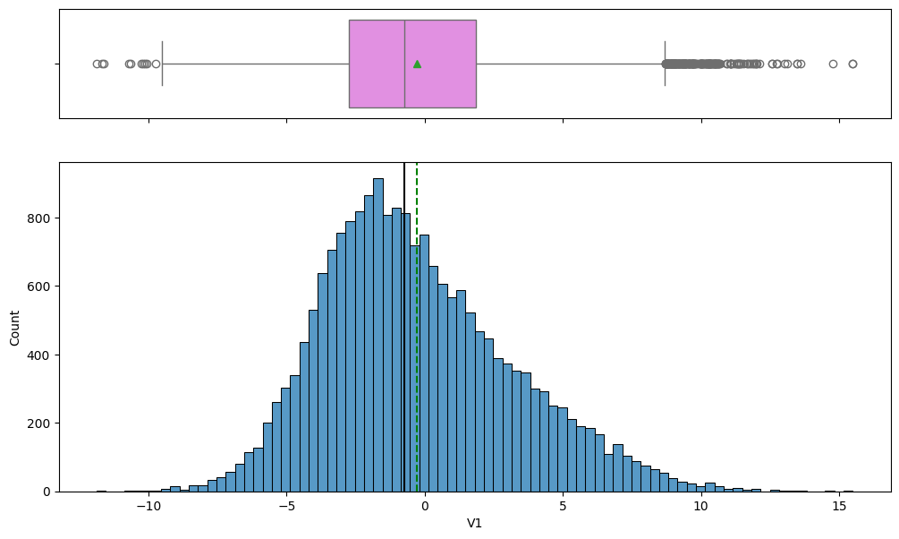

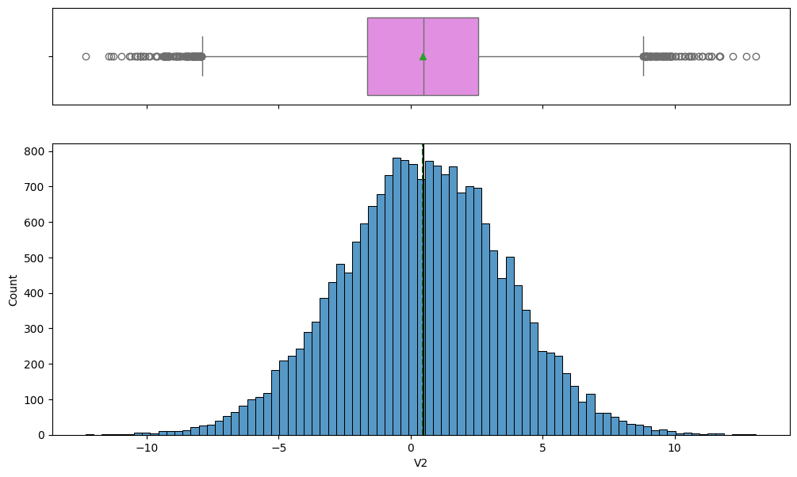

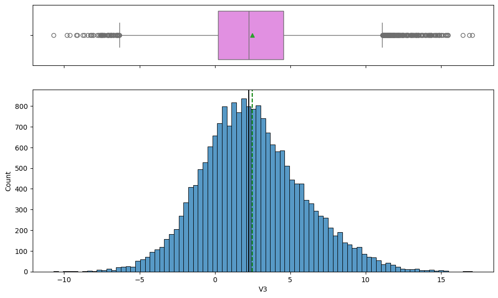

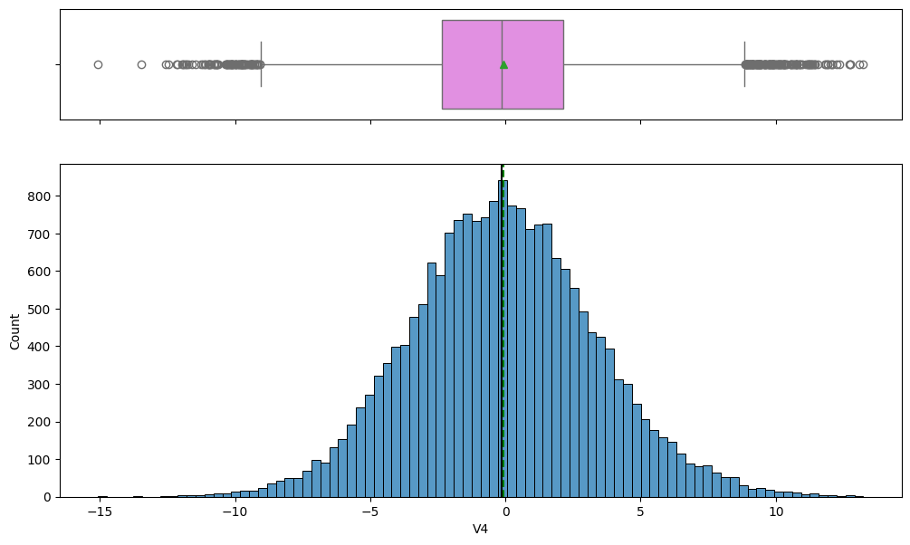

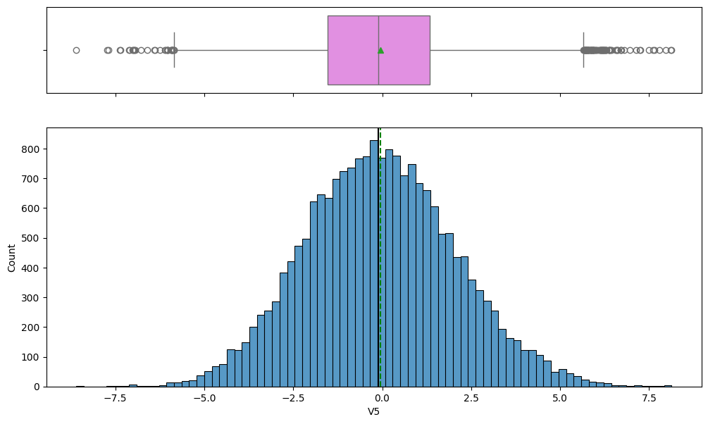

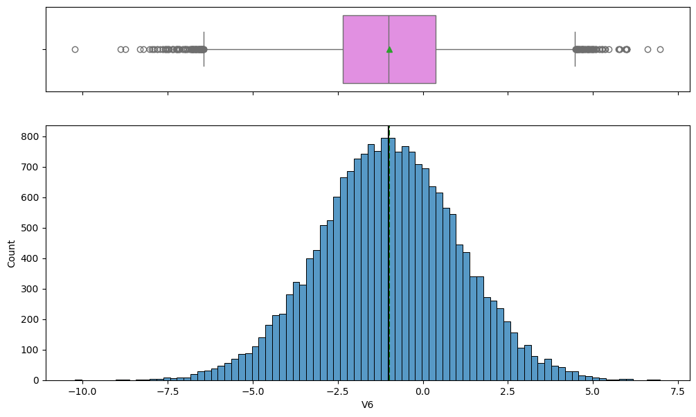

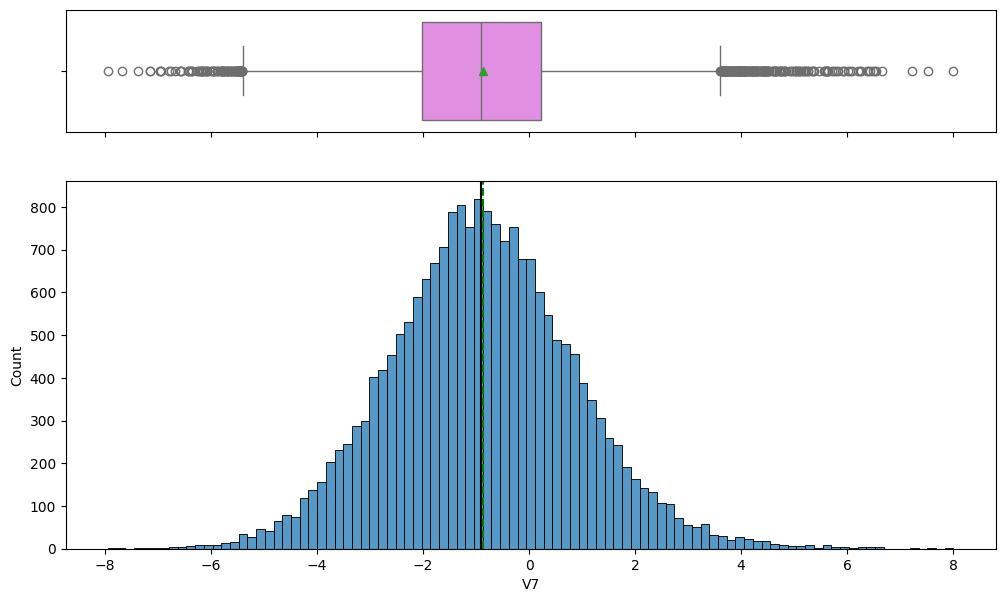

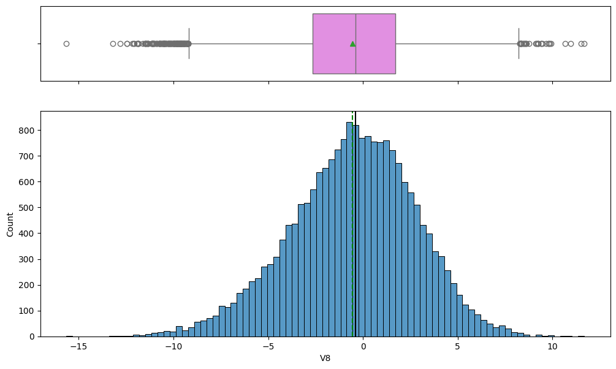

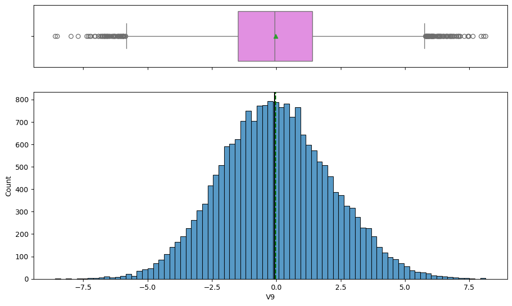

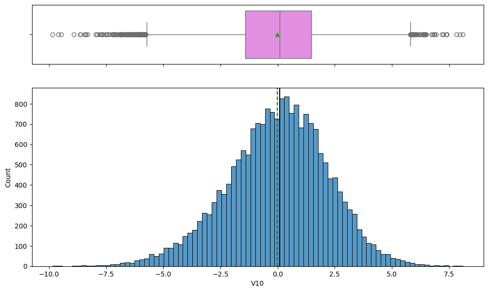

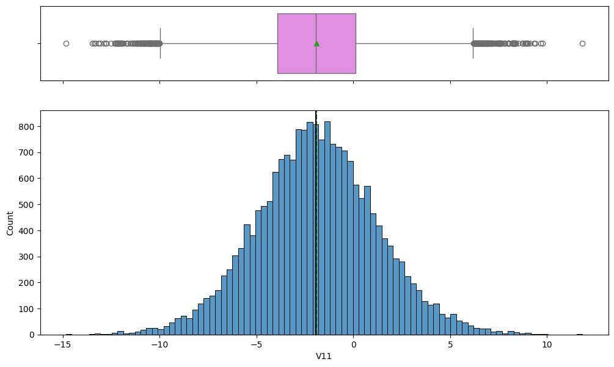

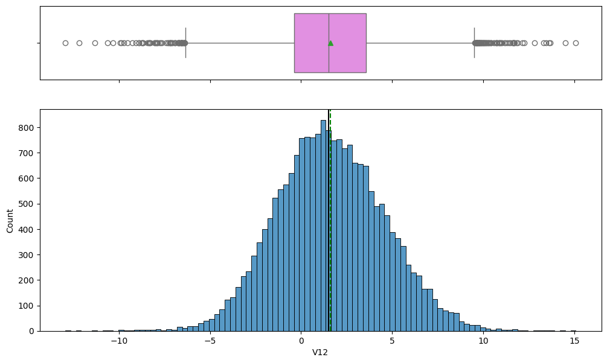

[29 more figures not shown]

```python
for feature in df_train.columns:
    histogram_boxplot(df_train, feature, figsize=(12, 7), kde=False, bins=None)
```

Observations/Insights from Histogram-Boxplot Visualizations:

## Data Pre-processing

```python
# Split Features (X) and Target (y) # Features
X = df_train.drop(columns=['Target']) # Target variable
y = df_train['Target']

# Split into Training (75%) and Validation (25%) sets
X_train, X_val, y_train, y_val = train_test_split(X, y, test_size=0.25, random_state=1, stratify=y)

# Display dataframe of shapes of the resulting datasets
shapes = {
    "Dataset": ["X_train", "X_val", "y_train", "y_val"],
    "Shape": [X_train.shape, X_val.shape, y_train.shape, y_val.shape]
}

# Display dataframe
pd.DataFrame(shapes)
```

|  | Dataset | Shape |
| --- | --- | --- |
| 0 | X_train | (15000, 40) |
| 1 | X_val | (5000, 40) |
| 2 | y_train | (15000,) |
| 3 | y_val | (5000,) |

Observations/Insights:

- The dataset has been successfully split
- This step is critical before imputation to avoid data leakage.

## Missing value imputation

```python
# Handle Missing Values (Imputation), fit the imputer on X_train, transform X_train, X_val, and X_test using the same imputer.

# Initialize imputer (Median Imputation)
imputer = SimpleImputer(strategy="median") # median used, variables are numeric in nature

# Fit only on X_train and transform
X_train = imputer.fit_transform(X_train)
X_val = imputer.transform(X_val)
X_test = imputer.transform(df_test.drop(columns=["Target"], errors="ignore"))

# Convert back to DataFrame to keep column names
columns = df_test.drop(columns=["Target"], errors="ignore").columns
X_train = pd.DataFrame(X_train, columns=columns)
X_val = pd.DataFrame(X_val, columns=columns)
X_test = pd.DataFrame(X_test, columns=columns)

# Check the shapes and ensure no missing values
print(f"X_train: {X_train.shape}, X_val: {X_val.shape}, X_test: {X_test.shape}")
print(f"Missing values in X_train: {X_train.isnull().sum().sum()}")
print(f"Missing values in X_test: {X_test.isnull().sum().sum()}")
```

```
X_train: (15000, 40), X_val: (5000, 40), X_test: (5000, 40)
Missing values in X_train: 0
Missing values in X_test: 0
```

Observations/Insights:

- No missing values remain in X_train or X_test, confirming successful imputation.
- The dataset shapes confirm:
  - X_train (15,000 rows, 40 features)
  - X_val (5,000 rows, 40 features)
  - X_test (5,000 rows, 40 features)

## Outlier Detection & Treatment (if needed)

- Tree-based models (XGBoost, Random Forest) can handle outliers better than linear models, but extreme outliers can still affect performance.
- Skewed distributions in some features may cause unstable model predictions.
- Precision & Recall balance may be impacted if extreme values dominate learning.
- If needed, Outlier treatment should be applied only to the training set and not the test set because:
  - Model Generalization: The test set should reflect real-world, unseen data.
  - Avoiding Data Leakage: Treating test data could cause information leakage, leading to overly optimistic performance.
  - Train Model on Realistic Data: The model should learn from a cleaned training set but be tested on original, untouched data.

```python
# Detect outliers in X_train & X_val, outputing the count

def detect_outliers_iqr(data):
  """
  Detects outliers using the Interquartile Range (IQR) method.

  Args:
    data: A pandas DataFrame or Series containing the data.

  Returns:
    A list of indices of the detected outliers.
  """
  q1 = data.quantile(0.25)
  q3 = data.quantile(0.75)
  iqr = q3 - q1
  lower_bound = q1 - 1.5 * iqr
  upper_bound = q3 + 1.5 * iqr
  outliers = data[(data < lower_bound) | (data > upper_bound)]
  return outliers

# Detect outliers in X_train and X_val
outlier_counts_train = {}
for column in X_train.columns:
    outliers = detect_outliers_iqr(X_train[column])
    outlier_counts_train[column] = len(outliers)

outlier_counts_val = {}
for column in X_val.columns:
    outliers = detect_outliers_iqr(X_val[column])
    outlier_counts_val[column] = len(outliers)

# Print the count of outliers in each column of X_train and X_val
print("Outlier counts in X_train:")
for column, count in outlier_counts_train.items():
    print(f"{column}: {count}")

print("\nOutlier counts in X_val:")
for column, count in outlier_counts_val.items():
    print(f"{column}: {count}")
```

```
Outlier counts in X_train:
V1: 172
V2: 130
V3: 206
V4: 172
V5: 95
V6: 117
V7: 220
V8: 144
V9: 122
V10: 153
V11: 198
V12: 121
V13: 215
V14: 92
V15: 399
V16: 173
V17: 216
V18: 561
V19: 110
V20: 118
V21: 195
V22: 180
V23: 78
V24: 214
V25: 83
V26: 187
V27: 120
V28: 129
V29: 261
V30: 181
V31: 178
V32: 161
V33: 290
V34: 597
V35: 239
V36: 177
V37: 103
V38: 120
V39: 138
```

[output cut: 28 more lines]

```
V26: 53
V27: 58
V28: 50
V29: 77
V30: 63
V31: 52
V32: 71
V33: 94
V34: 197
V35: 71
V36: 83
V37: 37
V38: 43
V39: 57
V40: 40
```

Observations:

- Extreme outliers observed across board.

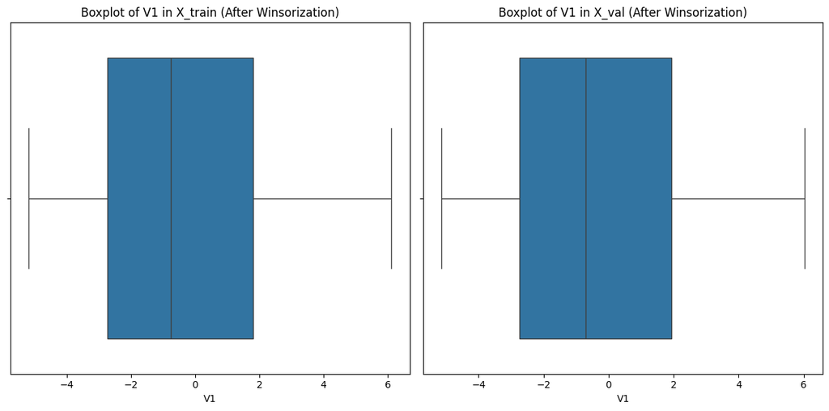

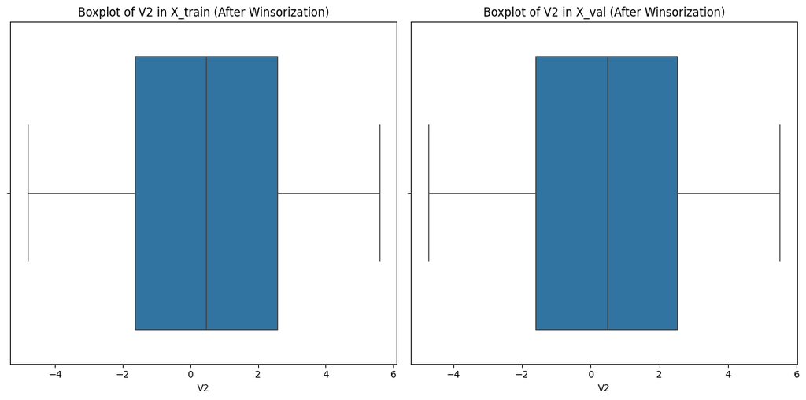

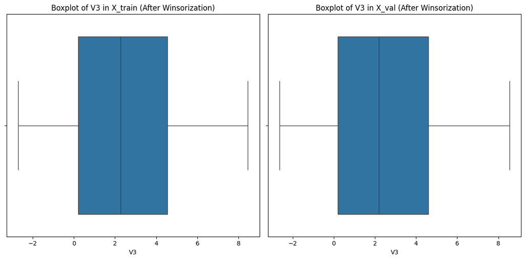

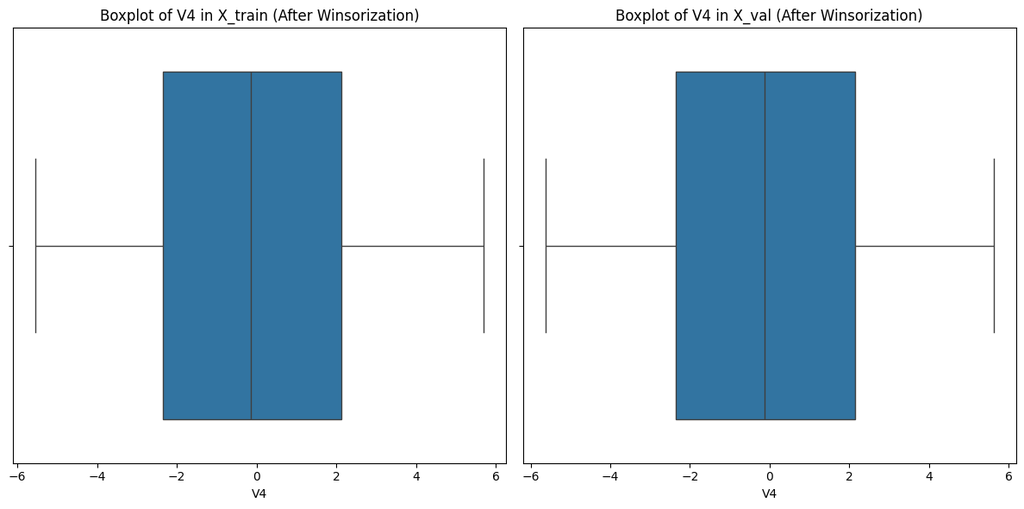

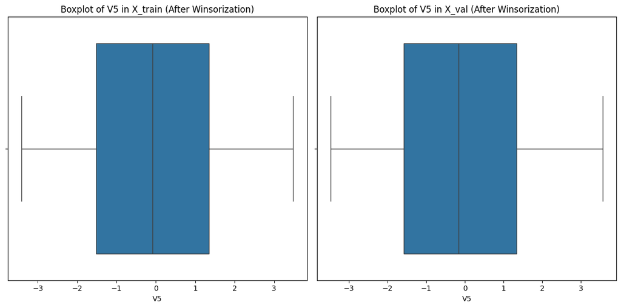

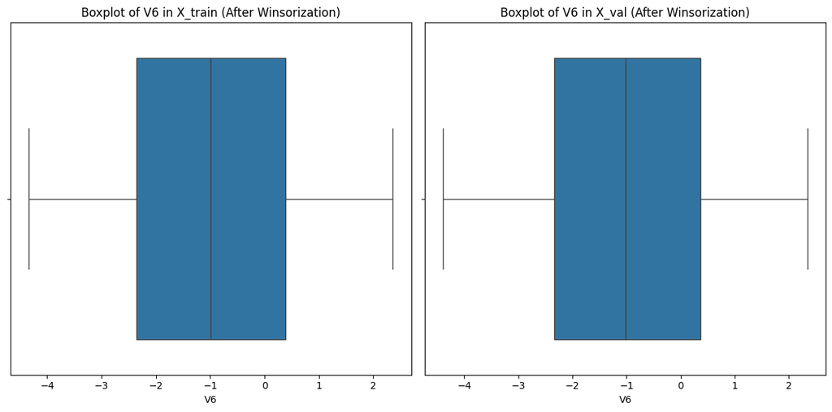

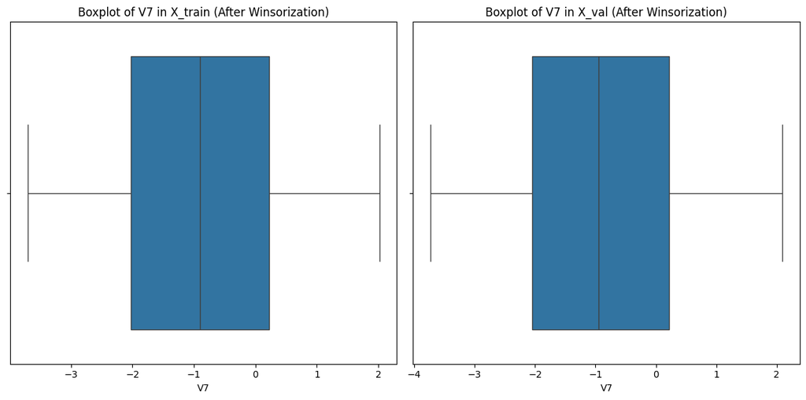

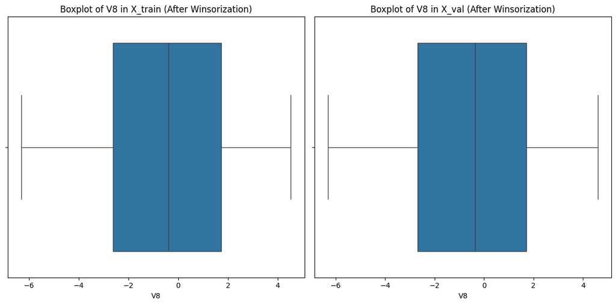

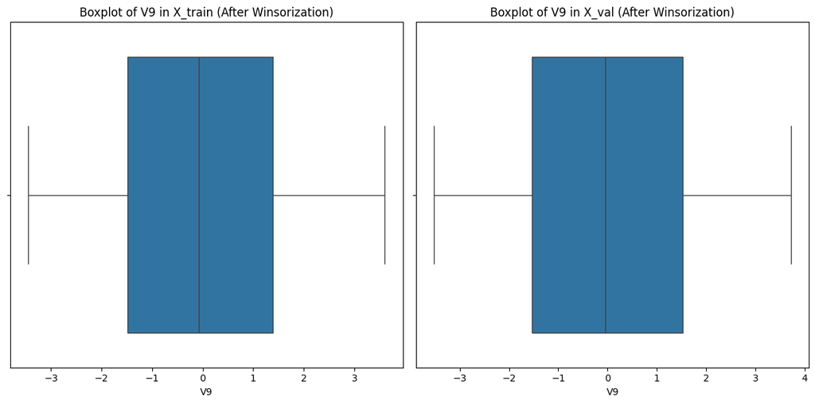

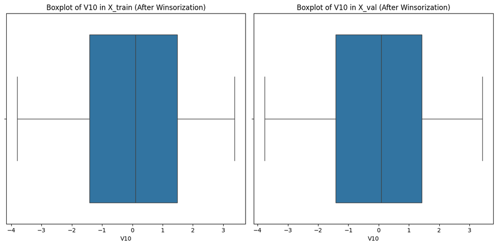

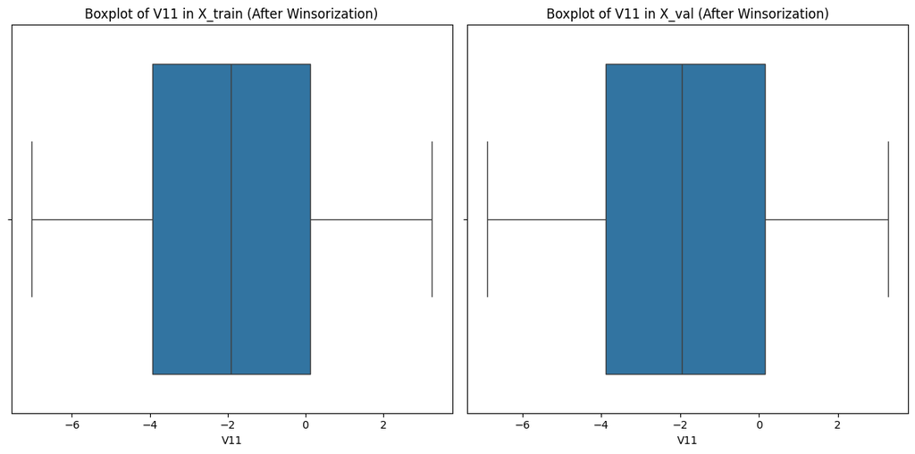

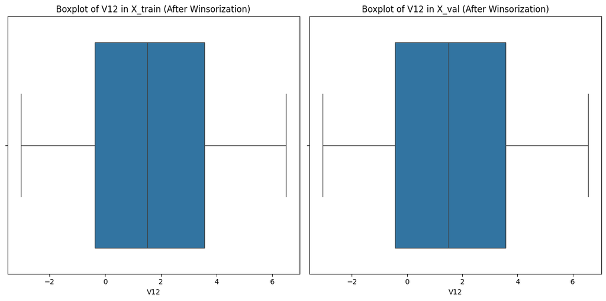

[28 more figures not shown]

```python
# Treat outliers in X_train, X_val using Winsorization capping

from scipy.stats.mstats import winsorize

for column in X_train.columns:
  X_train[column] = winsorize(X_train[column], limits=[0.05, 0.05])
  X_val[column] = winsorize(X_val[column], limits=[0.05, 0.05])

# Visualize treated outliers in X_train & X_val using boxplots
for feature in X_train.columns:
    plt.figure(figsize=(12, 6))
    plt.subplot(1, 2, 1)
    sns.boxplot(x=X_train[feature])
    plt.title(f"Boxplot of {feature} in X_train (After Winsorization)")

    plt.subplot(1, 2, 2)
    sns.boxplot(x=X_val[feature])
    plt.title(f"Boxplot of {feature} in X_val (After Winsorization)")

    plt.tight_layout()
    plt.show()
```

Observations:

- As observed, outliers duly treated/capped.

## Feature Scaling (Standardization or Normalization)

```python
# Initialize scaler
scaler = StandardScaler()

# Fit on training data only
X_train = scaler.fit_transform(X_train)

# Transform validation and test sets using the same scaler
X_val = scaler.transform(X_val)
X_test = scaler.transform(X_test)

# Check Final Shapes & Data Integrity
print(f"Final Shapes -> X_train: {X_train.shape}, X_val: {X_val.shape}, X_test: {X_test.shape}")
```

```
Final Shapes -> X_train: (15000, 40), X_val: (5000, 40), X_test: (5000, 40)
```

Observations/Insights:

- The data has been standardized
- This dataset has no categorical variables, there is no need to create dummy variables or apply encoding. Will proceed with model training using the numerical features directly.

## Model Building

### Model evaluation criterion

The nature of predictions made by the classification model will translate as follows:

- True positives (TP) are failures correctly predicted by the model.
- False negatives (FN) are real failures in a generator where there is no detection by model.
- False positives (FP) are failure detections in a generator where there is no failure.

**Which metric to optimize?**

- We need to choose the metric which will ensure that the maximum number of generator failures are predicted correctly by the model.
- We would want Recall to be maximized as greater the Recall, the higher the chances of minimizing false negatives.
- We want to minimize false negatives because if a model predicts that a machine will have no failure when there will be a failure, it will increase the maintenance cost.

**Let's define a function to output different metrics (including recall) on the train and test set and a function to show confusion matrix so that we do not have to use the same code repetitively while evaluating models.**

```python
# Defining a function to compute different metrics to check performance of a classification model built using sklearn
def model_performance_classification_sklearn(model, X, y):
    """
    Function to compute different metrics to check classification model performance

    model: classifier
    predictors: independent variables X
    target: dependent variable y
    """

def model_performance_classification_sklearn(model, X, y):
    y_pred = model.predict(X)
    return {
        "Accuracy": accuracy_score(y, y_pred),
        "Precision": precision_score(y, y_pred),
        "Recall": recall_score(y, y_pred),
        "F1 Score": f1_score(y, y_pred),
    }

    # Creating a dataframe of metrics
    df_perf = pd.DataFrame(
        {
            "Accuracy": acc,
            "Recall": recall,
            "Precision": precision,
            "F1": f1,
        },
        index=[0],
    )

    return df_perf
```

```python
def confusion_matrix_sklearn(model, predictors, target):
    """
    To plot the confusion_matrix with full precision percentages.

    model: classifier
    predictors: independent variables
    target: dependent variable
    """

    y_pred = model.predict(predictors)
    cm = confusion_matrix(target, y_pred)

    labels = np.array([
        [f"{item}\n{item / cm.sum():.6%}" for item in cm.flatten()]
    ]).reshape(2, 2)

    plt.figure(figsize=(6, 4))
    sns.heatmap(cm, annot=labels, fmt="", cmap="Blues")
    plt.ylabel("True label")
    plt.xlabel("Predicted label")
    plt.show()
```

### Defining scorer to be used for cross-validation and hyperparameter tuning

- We want to reduce false negatives and will try to maximize "Recall".
- To maximize Recall, we can use Recall as a **scorer** in cross-validation and hyperparameter tuning.

```python
# Type of scoring used to compare parameter combinations
scorer = metrics.make_scorer(metrics.recall_score)
```

### Model Building with original data

Sample Decision Tree model building with original data

```python
# Check class distribution in training and validation sets
class_distribution = pd.DataFrame({
    "Dataset": ["Train", "Validation"],
    "Class 0 Count": [sum(y_train == 0), sum(y_val == 0)],
    "Class 1 Count": [sum(y_train == 1), sum(y_val == 1)],
    "Class 1 Percentage": [sum(y_train == 1) / len(y_train) * 100, sum(y_val == 1) / len(y_val) * 100]
})

# Display class distribution
class_distribution
```

|  | Dataset | Class 0 Count | Class 1 Count | Class 1 Percentage |
| --- | --- | --- | --- | --- |
| 0 | Train | 14168 | 832 | 5.546667 |
| 1 | Validation | 4722 | 278 | 5.560000 |

```python
# Check shape of X_train and y_train
train_shapes = {
    "Dataset": ["X_train", "y_train"],
    "Shape": [X_train.shape, y_train.shape]
}

# Display dataframe
pd.DataFrame(train_shapes)
```

|  | Dataset | Shape |
| --- | --- | --- |
| 0 | X_train | (15000, 40) |
| 1 | y_train | (15000,) |

```python
models = []  # Empty list to store all the models

# Appending models into the list
models.append(("dtree", DecisionTreeClassifier(random_state=1)))
models.append(("logreg", LogisticRegression(random_state=1)))
models.append(("adaboost", AdaBoostClassifier(random_state=1)))
models.append(("bagging", BaggingClassifier(random_state=1)))
models.append(("rf", RandomForestClassifier(random_state=1)))
models.append(("xgb", XGBClassifier(random_state=1, eval_metric="logloss")))
models.append(("gb", GradientBoostingClassifier(random_state=1)))

results = []  # Empty list to store all model's CV scores
names = []  # Empty list to store name of the models


# loop through all models to get the mean cross validated score
print("\n" "Cross-Validation performance on training dataset:" "\n")

for name, model in models:
    scoring = "recall"
    kfold = StratifiedKFold(
        n_splits=3, shuffle=True, random_state=1
    )  # Setting number of splits equal to 3 for faster execution
    cv_result = cross_val_score(
        estimator=model, X=X_train, y=y_train, scoring=scorer, cv=kfold
    )
    results.append(cv_result)
    names.append(name)
    print("{}: {}".format(name, cv_result.mean() * 100))

print("\n" "Training Performance on Original Data:" "\n")

 # build models on original data
for name, model in models:
    model.fit(X_train, y_train)
    scores = recall_score(y_train, model.predict(X_train)) * 100
    print("{}: {}".format(name, scores))

print("\n" "Validation Performance on Original Data:" "\n")
for name, model in models:
    model.fit(X_train, y_train)
    scores = recall_score(y_val, model.predict(X_val)) * 100
    print("{}: {}".format(name, scores))
```

```
Cross-Validation performance on training dataset:

dtree: 70.07029755257167
logreg: 58.050454942904885
adaboost: 59.73863508471201
bagging: 67.78822429421085
rf: 69.5902483789142
xgb: 79.08474664311872
gb: 71.63381208390688

Training Performance on Original Data:

dtree: 100.0
logreg: 60.21634615384615
adaboost: 59.97596153846154
bagging: 96.03365384615384
rf: 100.0
xgb: 100.0
gb: 83.17307692307693

Validation Performance on Original Data:

dtree: 69.42446043165468
logreg: 58.992805755395686
adaboost: 61.51079136690647
bagging: 74.10071942446042
rf: 74.10071942446042
xgb: 82.37410071942446
gb: 75.89928057553958
```

Observations/Insights:

- Decision Tree, Random Forest, and XGBoost show 100% training accuracy, which indicates they are overfitting.
- This is confirmed by a performance drop in validation (Decision Tree drops from 100% to 69.42%).
- XGBoost (82.37%) has the best validation performance, meaning it generalizes well despite overfitting.
- Bagging and Random Forest (74.10%) also perform well, but not as good as XGBoost.
- Logistic Regression (58.99%) is the weakest, likely because the data has non-linear relationships that tree-based models handle better.

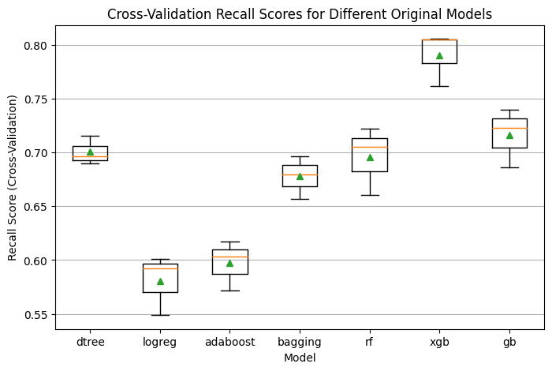

```python
# Collect cross-validation scores
results = []
names = []

for name, model in models:
    cv_result = cross_val_score(model, X_train, y_train, scoring="recall", cv=kfold)
    results.append(cv_result)
    names.append(name)

# Plot boxplot for cross-validation scores
plt.figure(figsize=(8, 5))
plt.boxplot(results, labels=names, showmeans=True)
plt.xlabel("Model")
plt.ylabel("Recall Score (Cross-Validation)")
plt.title("Cross-Validation Recall Scores for Different Original Models")
plt.grid(axis="y")

# Show the boxplot
plt.show()
```

Observations/Insights:

### Model Building with Oversampled data

```python
# Apply SMOTE to balance the dataset
sm = SMOTE(sampling_strategy=1, k_neighbors=5, random_state=1)
X_train_os, y_train_os = sm.fit_resample(X_train, y_train)

# Check class distribution after oversampling
class_distribution_os = pd.DataFrame({
    "Dataset": ["Train (Oversampled)", "Validation"],
    "Class 0 Count": [sum(y_train_os == 0), sum(y_val == 0)],
    "Class 1 Count": [sum(y_train_os == 1), sum(y_val == 1)],
    "Class 1 Percentage": [sum(y_train_os == 1) / len(y_train_os) * 100, sum(y_val == 1) / len(y_val) * 100]
})

# Display class distribution
class_distribution_os
```

|  | Dataset | Class 0 Count | Class 1 Count | Class 1 Percentage |
| --- | --- | --- | --- | --- |
| 0 | Train (Oversampled) | 14168 | 14168 | 50.00 |
| 1 | Validation | 4722 | 278 | 5.56 |

```python
# Check shape of X_train_os and y_train_os
train_os_shapes = {
    "Dataset": ["X_train_os", "y_train_os"],
    "Shape": [X_train_os.shape, y_train_os.shape]
}

# Display dataframe
pd.DataFrame(train_os_shapes)
```

|  | Dataset | Shape |
| --- | --- | --- |
| 0 | X_train_os | (28336, 40) |
| 1 | y_train_os | (28336,) |

```python
models = []  # Empty list to store all the models

# Appending models into the list
models.append(("dtree", DecisionTreeClassifier(random_state=1)))
models.append(("logreg", LogisticRegression(random_state=1)))
models.append(("adaboost", AdaBoostClassifier(random_state=1)))
models.append(("bagging", BaggingClassifier(random_state=1)))
models.append(("rf", RandomForestClassifier(random_state=1)))
models.append(("xgb", XGBClassifier(random_state=1, eval_metric="logloss")))
models.append(("gb", GradientBoostingClassifier(random_state=1)))

results = []  # Empty list to store all model's CV scores
names = []  # Empty list to store name of the models


# loop through all models to get the mean cross validated score
print("\n" "Cross-Validation performance on Oversampled training dataset:" "\n")


for name, model in models:
    scoring = "recall"
    kfold = StratifiedKFold(
        n_splits=3, shuffle=True, random_state=1
    )  # Setting number of splits equal to 3
    cv_result = cross_val_score(
        estimator=model, X=X_train_os, y=y_train_os, scoring=scorer, cv=kfold
    )
    results.append(cv_result)
    names.append(name)
    print("{}: {}".format(name, cv_result.mean() * 100))

print("\n" "Training Performance on Oversampled Training Dataset:" "\n")

for name, model in models:
    model.fit(X_train_os, y_train_os)
    scores = recall_score(y_train_os, model.predict(X_train_os)) * 100
    print("{}: {}".format(name, scores))

print("\n" "Validation Performance on Oversampled Training Dataset:" "\n")

for name, model in models:
    model.fit(X_train_os, y_train_os)
    scores = recall_score(y_val, model.predict(X_val)) * 100
    print("{}: {}".format(name, scores))
```

```
Cross-Validation performance on Oversampled training dataset:

dtree: 96.81677962063144
logreg: 89.25044380910549
adaboost: 89.99858428280697
bagging: 97.45907161893868
rf: 98.16488406169981
xgb: 98.99774785580573
gb: 92.24306100536427

Training Performance on Oversampled Training Dataset:

dtree: 100.0
logreg: 89.34923771880293
adaboost: 90.56324110671937
bagging: 99.87295313382269
rf: 100.0
xgb: 99.99294184076793
gb: 92.68068887634105

Validation Performance on Oversampled Training Dataset:

dtree: 80.93525179856115
logreg: 85.25179856115108
adaboost: 87.41007194244604
bagging: 82.73381294964028
rf: 83.81294964028777
xgb: 87.76978417266187
gb: 88.48920863309353
```

Observations/Insights:

Cross-Validation Performance on Oversampled Training Data:

- All models perform significantly better compared to the original dataset.
- XGBoost has the highest cross-validation performance (~99%).
- Random Forest, Bagging, and Decision Tree also show strong results.
- Logistic Regression improved, but it remains the lowest among the models.

Training Performance on Oversampled Data

- Major Overfitting: Decision Tree, Random Forest, and XGBoost all have 100% training accuracy, which suggests that they are memorizing the data rather than generalizing well.
- Bagging also overfits but slightly less than DT, RF, and XGB.
- Logistic Regression, AdaBoost, and Gradient Boosting are more balanced and may generalize better.

Validation Performance (Generalization Test):

- Gradient Boosting (88.49%) is the best model in validation, closely followed by XGBoost (87.77%) and AdaBoost (87.41%)

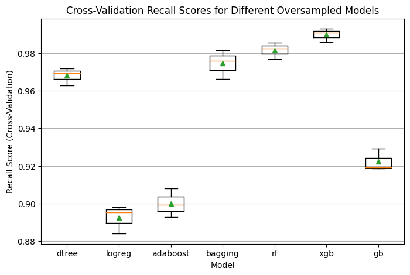

```python
# Collect cross-validation scores
results = []
names = []

for name, model in models:
    cv_result = cross_val_score(model, X_train_os, y_train_os, scoring="recall", cv=kfold)
    results.append(cv_result)
    names.append(name)

# Plot boxplot for cross-validation scores
plt.figure(figsize=(8, 5))
plt.boxplot(results, labels=names, showmeans=True)
plt.xlabel("Model")
plt.ylabel("Recall Score (Cross-Validation)")
plt.title("Cross-Validation Recall Scores for Different Oversampled Models")
plt.grid(axis="y")

# Show the boxplot
plt.show()
```

Observations/Insights:

### Model Building with Undersampled data

```python
# Apply random undersampling
rus = RandomUnderSampler(random_state=1, sampling_strategy=1)  # Equalize both classes
X_train_un, y_train_un = rus.fit_resample(X_train, y_train)

# Check class distribution in training and validation sets
class_distribution = pd.DataFrame({
    "Dataset": ["Train (Undersampled)", "Validation"],
    "Class 0 Count": [sum(y_train_un == 0), sum(y_val == 0)],
    "Class 1 Count": [sum(y_train_un == 1), sum(y_val == 1)],
    "Class 1 Percentage": [sum(y_train_un == 1) / len(y_train_un) * 100, sum(y_val == 1) / len(y_val) * 100]
})

# Display class distribution dataframe
class_distribution
```

|  | Dataset | Class 0 Count | Class 1 Count | Class 1 Percentage |
| --- | --- | --- | --- | --- |
| 0 | Train (Undersampled) | 832 | 832 | 50.00 |
| 1 | Validation | 4722 | 278 | 5.56 |

```python
# Check shape of X_train_un and y_train_un
train_shapes = {
    "X_train_un Shape": X_train_un.shape[0],  # Use only the first element of the shape (number of rows)
    "y_train_un Shape": y_train_un.shape[0]   # Use only the first element of the shape (number of rows)
}

# Display dataframe
pd.DataFrame(train_shapes, index=[0]) # Create a single-row DataFrame
```

|  | X_train_un Shape | y_train_un Shape |
| --- | --- | --- |
| 0 | 1664 | 1664 |

```python
models = []  # Empty list to store all the models

# Appending models into the list
models.append(("dtree", DecisionTreeClassifier(random_state=1)))
models.append(("logreg", LogisticRegression(random_state=1)))
models.append(("adaboost", AdaBoostClassifier(random_state=1)))
models.append(("bagging", BaggingClassifier(random_state=1)))
models.append(("rf", RandomForestClassifier(random_state=1)))
models.append(("xgb", XGBClassifier(random_state=1, eval_metric="logloss")))
models.append(("gb", GradientBoostingClassifier(random_state=1)))

results = []  # Empty list to store all model's CV scores
names = []  # Empty list to store name of the models


# loop through all models to get the mean cross validated score
print("\n" "Cross-Validation Performance on Undersampled Dataset:" "\n")

for name, model in models:
    scoring = "recall"
    kfold = StratifiedKFold(
        n_splits=3, shuffle=True, random_state=1
    )  # Setting number of splits equal to 3
    cv_result = cross_val_score(
        estimator=model, X=X_train_un, y=y_train_un, scoring=scorer, cv=kfold
    )
    results.append(cv_result)
    names.append(name)
    print("{}: {}".format(name, cv_result.mean() * 100))

print("\n" "Training Performance on Undersampled Dataset:" "\n")

for name, model in models:
    model.fit(X_train_un, y_train_un)
    scores = recall_score(y_train_un, model.predict(X_train_un)) * 100
    print("{}: {}".format(name, scores))

print("\n" "Validation Performance on Undersampled Dataset:" "\n")
for name, model in models:
    model.fit(X_train_un, y_train_un)
    scores = recall_score(y_val, model.predict(X_val)) * 100
    print("{}: {}".format(name, scores))
```

```
Cross-Validation Performance on Undersampled Dataset:

dtree: 85.69418833164515
logreg: 87.37890553982807
adaboost: 88.09876286696276
bagging: 86.53871126925173
rf: 89.54237332155937
xgb: 90.26352924880312
gb: 89.66271026500098

Training Performance on Undersampled Dataset:

dtree: 100.0
logreg: 87.86057692307693
adaboost: 90.38461538461539
bagging: 98.5576923076923
rf: 100.0
xgb: 100.0
gb: 94.59134615384616

Validation Performance on Undersampled Dataset:

dtree: 87.05035971223022
logreg: 86.6906474820144
adaboost: 86.33093525179856
bagging: 86.33093525179856
rf: 89.20863309352518
xgb: 89.92805755395683
gb: 89.20863309352518
```

Observations/Insights:

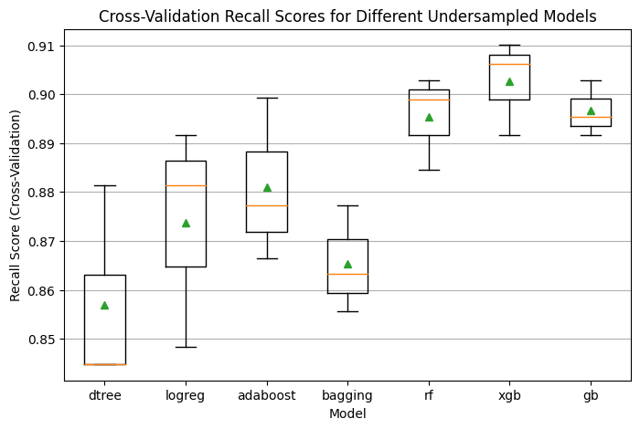

```python
# Collect cross-validation scores
results = []
names = []

for name, model in models:
    cv_result = cross_val_score(model, X_train_un, y_train_un, scoring="recall", cv=kfold)
    results.append(cv_result)
    names.append(name)

# Plot boxplot for cross-validation scores
plt.figure(figsize=(8, 5))
plt.boxplot(results, labels=names, showmeans=True)
plt.xlabel("Model")
plt.ylabel("Recall Score (Cross-Validation)")
plt.title("Cross-Validation Recall Scores for Different Undersampled Models")
plt.grid(axis="y")

# Show the boxplot
plt.show()
```

Observations/Insights:

### Model Performance Comparision

```python
# Create a DataFrame to summarize the model performance from the extracted results

# Model names
models = ["dtree", "logreg", "adaboost", "bagging", "rf", "xgb", "gb"]

# Extracted results for Training & Validation Recall Scores
train_recall_scores = {
    "Original": [100.0, 60.22, 59.98, 96.03, 100.0, 100.0, 83.17],
    "Oversampled": [100.0, 89.35, 90.56, 99.87, 100.0, 99.99, 92.68],
    "Undersampled": [100.0, 87.86, 90.38, 98.56, 100.0, 100.0, 94.59],
}

val_recall_scores = {
    "Original": [69.42, 58.99, 61.51, 74.10, 74.10, 82.37, 75.89],
    "Oversampled": [80.94, 85.25, 87.41, 82.73, 83.81, 87.77, 88.49],
    "Undersampled": [87.05, 86.69, 86.33, 86.33, 89.21, 89.93, 89.21],
}

# Convert to DataFrame
df_model_performance = pd.DataFrame({
    "Model": models,
    "Train Recall (Original)": train_recall_scores["Original"],
    "Val Recall (Original)": val_recall_scores["Original"],
    "Train Recall (Oversampled)": train_recall_scores["Oversampled"],
    "Val Recall (Oversampled)": val_recall_scores["Oversampled"],
    "Train Recall (Undersampled)": train_recall_scores["Undersampled"],
    "Val Recall (Undersampled)": val_recall_scores["Undersampled"],
})

# Sort by highest validation recall (best generalization performance)
df_model_performance["Best Validation Recall"] = df_model_performance[
    ["Val Recall (Original)", "Val Recall (Oversampled)", "Val Recall (Undersampled)"]
].max(axis=1)

df_model_performance_sorted = df_model_performance.sort_values(by="Best Validation Recall", ascending=False)

# Display model performance summary
pd.DataFrame(df_model_performance_sorted)
```

|  | Model | Train Recall (Original) | Val Recall (Original) | Train Recall (Oversampled) | Val Recall (Oversampled) | Train Recall (Undersampled) | Val Recall (Undersampled) | Best Validation Recall |
| --- | --- | --- | --- | --- | --- | --- | --- | --- |
| 5 | xgb | 100.00 | 82.37 | 99.99 | 87.77 | 100.00 | 89.93 | 89.93 |
| 4 | rf | 100.00 | 74.10 | 100.00 | 83.81 | 100.00 | 89.21 | 89.21 |
| 6 | gb | 83.17 | 75.89 | 92.68 | 88.49 | 94.59 | 89.21 | 89.21 |
| 2 | adaboost | 59.98 | 61.51 | 90.56 | 87.41 | 90.38 | 86.33 | 87.41 |
| 0 | dtree | 100.00 | 69.42 | 100.00 | 80.94 | 100.00 | 87.05 | 87.05 |
| 1 | logreg | 60.22 | 58.99 | 89.35 | 85.25 | 87.86 | 86.69 | 86.69 |
| 3 | bagging | 96.03 | 74.10 | 99.87 | 82.73 | 98.56 | 86.33 | 86.33 |

Observations/Insight:

Top 4 Models (Based on Best Validation Recall):

1. XGBoost (xgb) - 89.93% Recall
2. Random Forest (rf) - 89.21% Recall
3. Gradient Boosting (gb) - 89.21% Recall
4. Adaboost (adaboost) - 87.41% Recall
- These models demonstrated the best generalization ability, meaning they are most effective in detecting failures while minimizing false negatives.
- *Will fine-tune these models for further improved performance*

## HyperparameterTuning

#### XGBoost (xgb)

##### xgb original tuned

```
Fitting 3 folds for each of 30 candidates, totalling 90 fits
Best parameters are {'subsample': 0.8, 'scale_pos_weight': 10, 'n_estimators': 250, 'learning_rate': 0.1, 'gamma': 0} with CV score=0.9896666666666666:
Training Performance:
 {'Accuracy': 1.0, 'Precision': 1.0, 'Recall': 1.0, 'F1 Score': 1.0}

Validation Performance:
 {'Accuracy': 0.99, 'Precision': 0.9672131147540983, 'Recall': 0.8489208633093526, 'F1 Score': 0.9042145593869731}
```

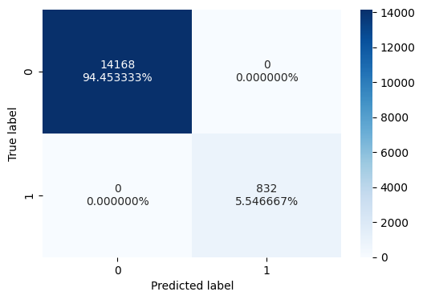

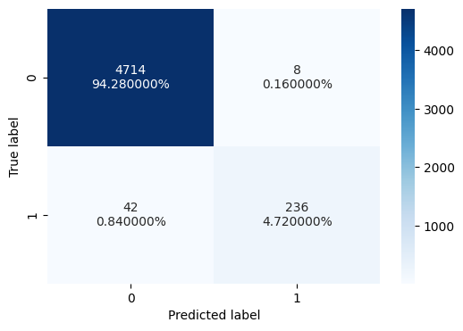

```python
xgb_tuned = XGBClassifier(eval_metric='logloss')

param_grid={ 'n_estimators': [150, 200, 250],
            'scale_pos_weight': [5,10],
             'learning_rate': [0.1,0.2],
             'gamma': [0,3,5],
             'subsample': [0.8,0.9] }

# Initialize random grid
randomized_cv = RandomizedSearchCV(estimator=xgb_tuned, param_distributions=param_grid,
                                n_iter=30, cv=3, verbose=2, n_jobs=-1, random_state=1)

# Fit the model
randomized_cv.fit(X_train, y_train)

# Print the best parameters and corresponding CV score
print("Best parameters are {} with CV score={}:" .format(randomized_cv.best_params_, randomized_cv.best_score_))

# Get best parameters and best model
best_params_xgb_tuned = randomized_cv.best_params_
best_model_xgb_tuned = randomized_cv.best_estimator_

# Fit the best model on the training data
best_model_xgb_tuned.fit(X_train, y_train)

# Training Performance
xgb_random_train_perf = model_performance_classification_sklearn(best_model_xgb_tuned, X_train, y_train)
print("Training Performance:\n", xgb_random_train_perf)

# Validation Performance
xgb_random_val_perf = model_performance_classification_sklearn(best_model_xgb_tuned, X_val, y_val)
print("\nValidation Performance:\n", xgb_random_val_perf)

# Create confusion matrix Train
confusion_matrix_sklearn(best_model_xgb_tuned, X_train, y_train)

# Create confusion matrix Validation
confusion_matrix_sklearn(best_model_xgb_tuned, X_val, y_val)
```

Observations/Insights:

- The tuned XGBoost model generalizes well with high recall (84.89%) and excellent precision (96.72%).
- Avoids too many false positives, making it reliable for deployment.
- Slight risk of overfitting in training. Consider increasing gamma or reg_lambda to improve generalization.